# progress_meeting

2023-11-03

## Climate change, temperature persistence patterns, and effects to the performance and distribution of native and invasive small aquatic plant populations

Debora Andrade-Pereira  
November, 2023

## Agenda

- My current and upcoming projects
- Autocorrelation of temperatures:
  - Overview
  - Previous questions from committee
  - Preliminary experiment results
- Distribution model and invasion risk: draft manuscript

## My current and upcoming projects

- Certificate in university teaching
- Experiments:
  - Night warming
  - Autocorrelation in temperatures
  - Population growth (some generations)
- Models:
  - Population models
  - Distribution models: manuscript in progress

## Autocorrelation in temperatures: overview

[figure not shown]

## Autocorrelation in temperatures: overview

- lag 1: hourly temperature changes

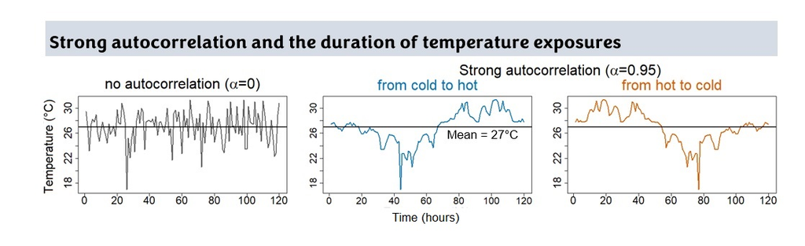

## Autocorrelation in temperatures: overview

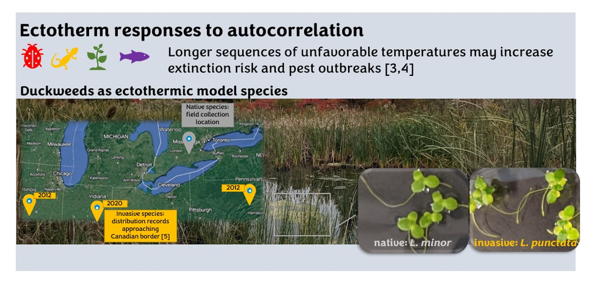

## Autocorrelation in temperatures: hypotheses

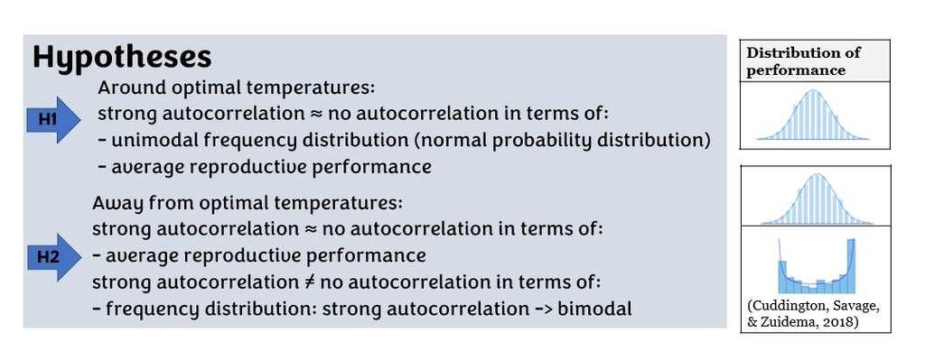

## Autocorrelation in temperatures: hypotheses

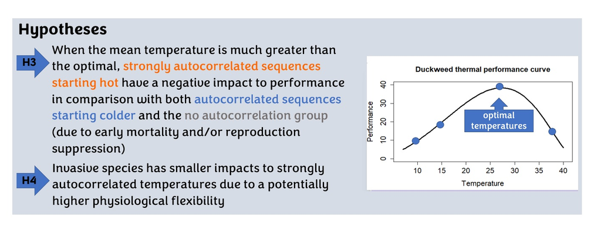

## Before checking out results: Addressing your previous comments

- A pairwise comparison of a native and an invasive species in monoculture is limited
- It would be nice to have a survival analysis for the autocorrelation in temperatures experiment
- Why did you include nesting if your statistical analysis consists of interactions between average temperature and autocorrelation treatments as independent variables?

## Comment: A pairwise comparison of a native and an invasive species in monoculture is limited

- Limitation: without replicating experiment using more species, little can be concluded except for species differences  
  *My justifications for doing a pairwise study including only 2 species*
- A number of studies include a comparison between 2 species (e.g., duckweed invasion in Europe, *L. minuta* x *L. minor*; night warming studies)
- Several cosmopolitan duckweed species share similar ecological features (e.g., thermal performance; negative density dependence; habitat; survival and reproductive strategies)

## Autocorrelation in temperatures: preliminary experiment results

Overview of dataset: data we typically collect in a given experimental run (5 days)

|  | Experiment_Number | Experiment_Start | Experiment_End | Profile_name |
| --- | --- | --- | --- | --- |
| 4 | 76 | 15-Sep-22 | 20-Sep-22 | simplelong10_000_6 |
| 5 | 76 | 15-Sep-22 | 20-Sep-22 | simplelong10_000_6 |
| 6 | 76 | 15-Sep-22 | 20-Sep-22 | simplelong10_095_6 |
| 7 | 76 | 15-Sep-22 | 20-Sep-22 | simplelong10_095_6 |
| 8 | 76 | 15-Sep-22 | 20-Sep-22 | simplelong10_095rev_6 |
| 9 | 76 | 15-Sep-22 | 20-Sep-22 | simplelong10_095rev_6 |

## Autocorrelation in temperatures: preliminary experiment results

Overview of dataset

|  | Mean_temperature | Treatment | Incubator | Species |
| --- | --- | --- | --- | --- |
| 4 | 10 | 0 | 3 | Field_LM |
| 5 | 10 | 0 | 3 | LP |
| 6 | 10 | 0.95 | 4 | Field_LM |
| 7 | 10 | 0.95 | 4 | LP |
| 8 | 10 | 0.95 | 5 | Field_LM |
| 9 | 10 | 0.95 | 5 | LP |

## Autocorrelation in temperatures: preliminary experiment results

Overview of dataset

|  | Frond_count_1 | Frond_count_2 | Frond_count_3 | Dead_frond_count_1 |
| --- | --- | --- | --- | --- |
| 4 | 5 | 6 | 5 | NA |
| 5 | 7 | 5 | 5 | NA |
| 6 | 6 | 7 | 7 | NA |
| 7 | 6 | 6 | 7 | NA |
| 8 | 7 | 8 | 7 | NA |
| 9 | 7 | 6 | 6 | NA |

## Data validation and data cleaning

Excluding failed experiments outside established parameters:

- Experiment duration (120h +- 1h)
- Standard deviation (2.5ºC +- 0.4ºC)
- Autocorrelation (ρ=0 or ρ=0.95 +-0.3)

## Types of measurement I am taking

- Population counts: living and dead frond counts
- Surface area (not shown here)
- Relative growth rate: frond count and surface area

\[ RGR = ((log(Nf)-log(Ni))/t) \]

Where  
Nf = final number of fronds (individuals); Ni = initial number of fronds; t = time in days

## This is the number of replicates for each treatment

- Subsampling done to remove duplicate “strong autocorrelation” replicates (i.e., starting hot or starting cold)

| Temperature | no autocorrelation | strong autocorrelation |
| --- | --- | --- |
| 10-15 | 20 | 17 |
| 27 | 12 | 13 |
| 37 | 14 | 14 |

## H1: Optimal temperatures: strong autocorrelation ≈ no autocorrelation

in terms of  
- mean reproductive performance  
- distribution of performance (normal distribution)

This analysis is restricted to the relative growth rate of *Lemna minor*

## Mean reproductive performance

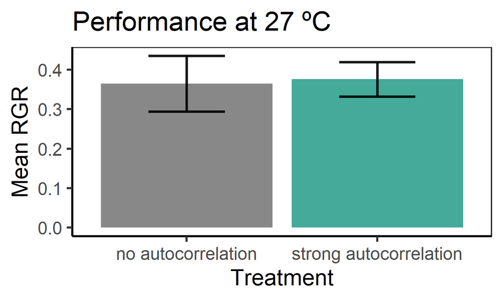

## H1: Frequency distribution

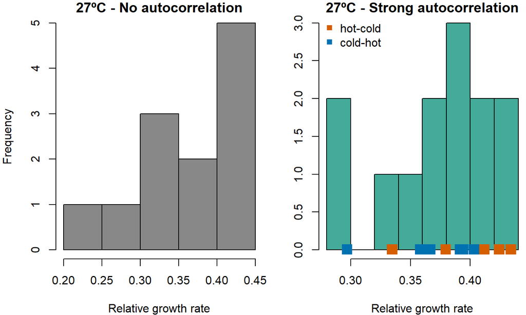

## H2: Away from optimum, strong autocorrelation ≈ no autocorrelation

- Cold: Mean reproductive performance

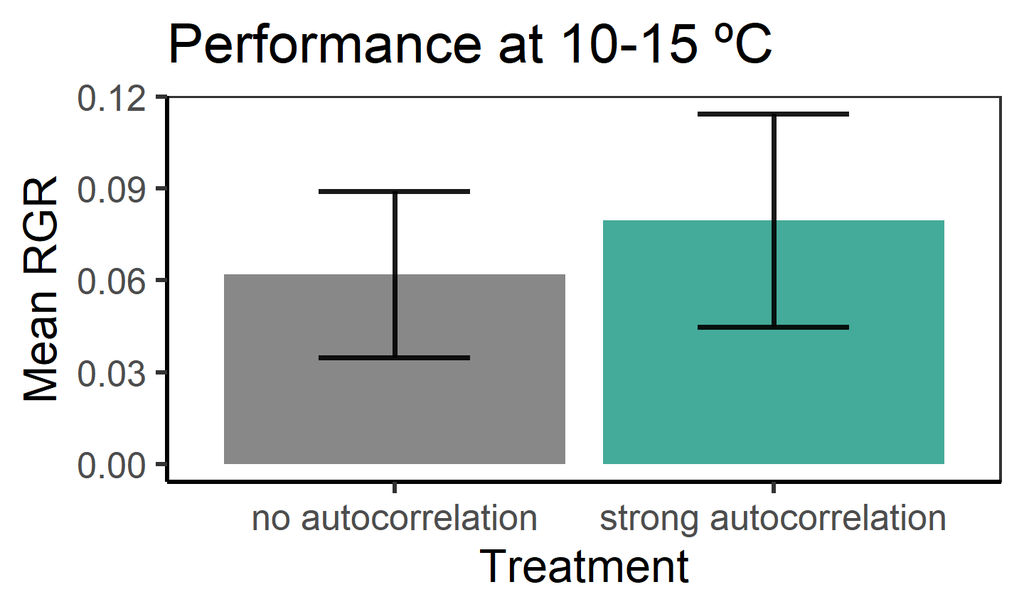

## H2: Away from optimum, strong autocorrelation ≠ no autocorrelation

- Cold: Frequency distribution of performance (bimodal)

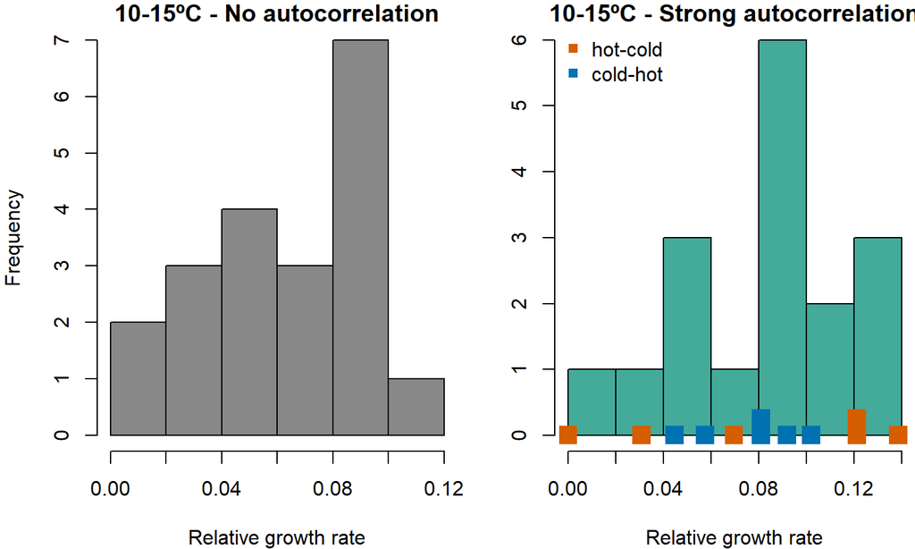

## H2: When it’s too hot…

- Mean performance

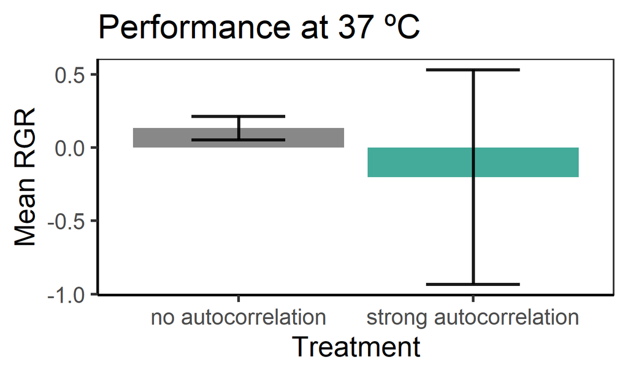

## H2: Frequency distribution (hot)

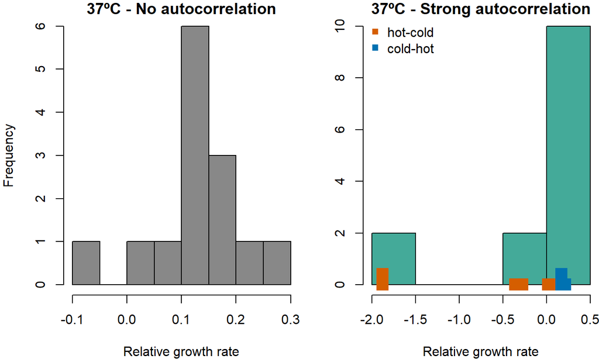

## What about initial conditions of exposure, do they matter?

H3: superoptimal conditions: strong autocorrelation starting hot -> negative impact to performance

- in comparison with autocorrelated sequences starting colder and the no autocorrelation group
- early mortality and/or reproduction suppression

-> effects are more intense in superoptimal temperatures: thermal performance curve shape

-> negative responses will not be observed to the same extent in mean temperatures which are lower or around optimal conditions

## “Strong autocorrelation” group subdivided into:

cold-hot and hot-cold

- New number of replicates:

| Temperature | hot-cold | cold-hot | no autocorrelation |
| --- | --- | --- | --- |
| 10-15 | 17 | 18 | 20 |
| 27 | 11 | 12 | 12 |
| 37 | 11 | 12 | 14 |

## Comparing performance across temperatures

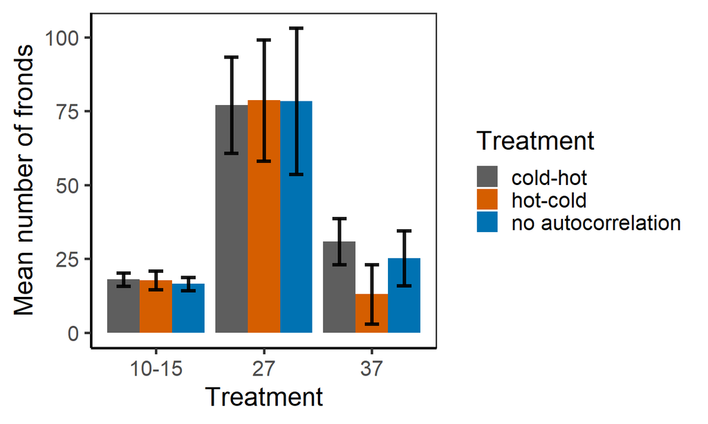

## Candidate model assessment

- Poisson model for count data (total number of individuals at the end of experiment period)
- Crossed design (factorial) including interactions between treatments and average temperatures

```
## Random effect variances not available. Returned R2 does not account for random effects.
```

| Name | Model | AIC | AIC_wt |
| --- | --- | --- | --- |
| no random effects | glm | 1046.63 | 0.00 |
| experiment number | glmerMod | 886.04 | 0.73 |
| incubator | glmerMod | 1042.11 | 0.00 |
| incubator and experiment number | glmerMod | 888.04 | 0.27 |
| incubator nested in experiment number | glmerMod | 940.25 | 0.00 |

## Selected model

```
## $call
## glmer(formula = Frond_count ~ Treatment * Mean_temperature +
##     (1 | Experiment_Number), data = datin, family = "poisson")
```

## Results from best model

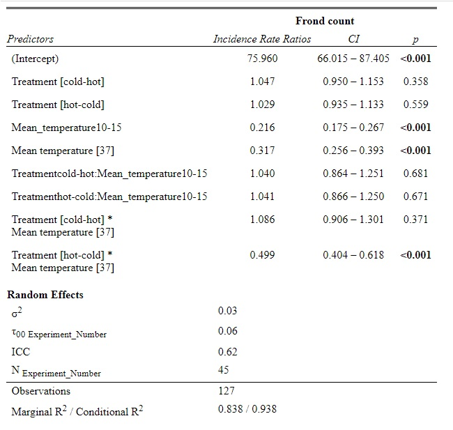

## Taking a look at survival data

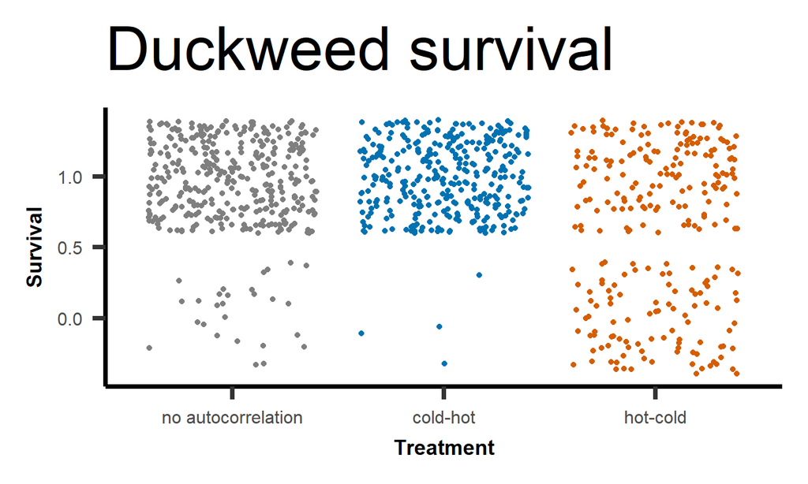

## Candidate models (logistic fit, binomial data: 1=survival; 0=mortality)

[output not shown]

| Name | Model | AIC | AIC_wt |
| --- | --- | --- | --- |
| no random effects | glm | 588.66 | 0.00 |
| experiment number | glmerMod | 500.46 | 0.00 |
| incubator | glmerMod | 569.04 | 0.00 |
| dish | glmerMod | 590.66 | 0.00 |
| incubator, dish, and experiment number | glmerMod | 496.59 | 0.00 |
| incubator and dish | glmerMod | 571.04 | 0.00 |
| incubator and experiment number | glmerMod | 494.59 | 0.00 |
| dish and experiment number | glmerMod | 502.46 | 0.00 |
| incubator nested in experiment number, and dish | glmerMod | 480.60 | 0.27 |
| incubator nested in experiment number | glmerMod | 478.60 | 0.73 |

## Selected model

The best model includes incubator number nested in experiment number as a random effect

[output not shown]

## Statistical analysis of selected model

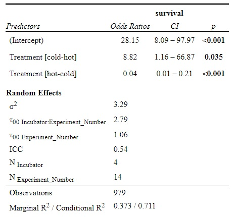

The hot-cold strong autocorrelation treatment is significantly different than the control (zero autocorrelation).

## Plotting survival probability as estimated by the model

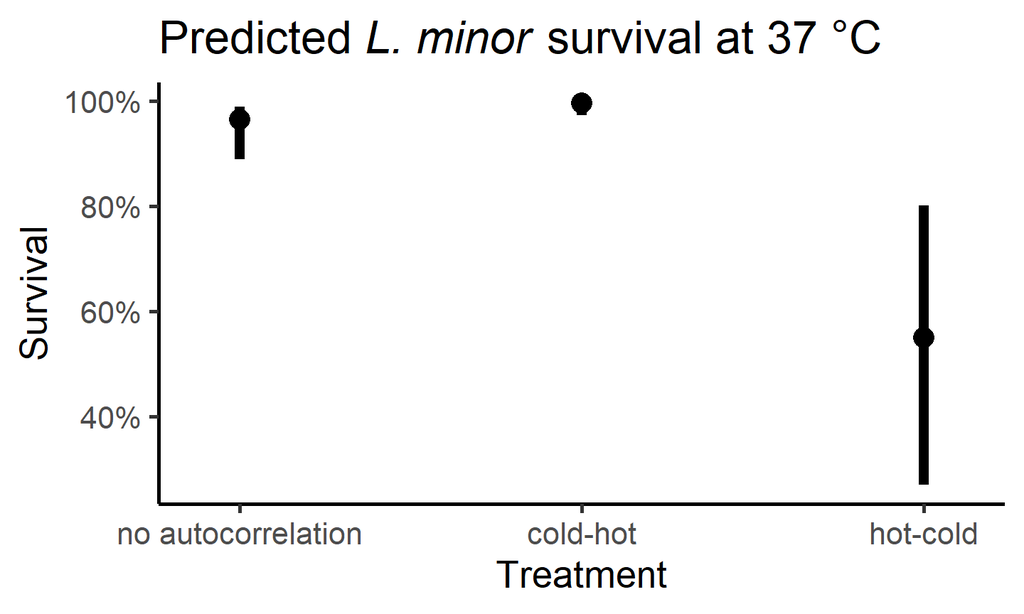

## Post-hoc analyses

|  | 1 | estimate | SE | df | z.ratio | p.value |
| --- | --- | --- | --- | --- | --- | --- |
| 2 | no autocorrelation - (hot-cold) | 3.1356 | 0.7924 | Inf | 3.9569 | 0.0002 |
| 3 | (cold-hot) - (hot-cold) | 5.3123 | 1.0852 | Inf | 4.8952 | 0.0000 |

## Including a comparison between species

H4: When the mean temperature is much greater than the optimal, the invasive species has smaller impacts to strongly autocorrelated temperatures due to a potentially higher physiological flexibility (Harvey et al., 2020)

## General linear model, Poisson distribution (count data)

| Name | Model | AIC | AIC_wt |
| --- | --- | --- | --- |
| no random effects | glm | 767.62 | 0 |
| experiment number | glmerMod | 671.34 | 0 |
| incubator | glmerMod | 762.85 | 0 |
| incubator and experiment number | glmerMod | 666.04 | 0 |
| incubator nested in experiment number | glmerMod | 627.36 | 1 |

## Selected model

The best model is the one including incubator number nested in experiment number as a random effect

```
## $call
## glmer(formula = Frond_count ~ Treatment * Species + (1 | Experiment_Number/Incubator),
##     data = datin, family = "poisson")
```

## Results from best model

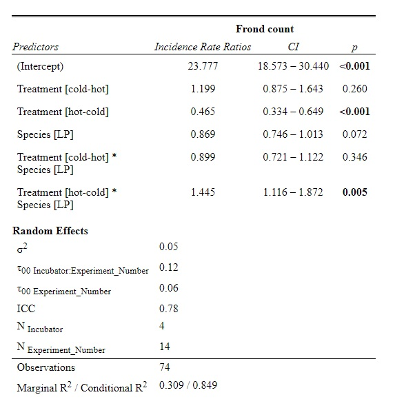

## Draft manuscript: predicting the distribution of an invasive duckweed species

Draft title: Predicting the risk of range expansion for a newly established invasive duckweed species in Europe and Canada

- *Landoltia punctata* is an invasive duckweed in the US:
  - dense mats: modifies habitats, suppresses other species
  - herbicide resistance
  - high management costs
  - loss of recreational areas

## Draft manuscript: predicting the distribution of an invasive duckweed species

- Canada: distribution records approaching Great Lakes region (associated with climate change)
- Europe: recent observations (preliminary studies: low risk; similar ecology)
- New examination of risks:
  - continental invasion in the US
  - similar recent invasion in Europe (*L. minuta*)

## Methods

- Predicting distribution of *L. punctata* in Europe and Canada: Maxent approach
- Restricted set of predictors
- 518 occurrence records and 3 bioclimatic variables related to life history
- Satellite temperature measurements of surface lake water (more relevant to macrophytes)

## Preliminary results and discussion

- Best model: good predictive capability (training set AUC = 0.9; testing set AUC = 0.81)
- Models based on water temperature are more accurate than the ones including air temperature
- Restricted set of predictors resulted in unimodal response curves ressembling thermal performance curves
- Model suggests high habitat suitability:
  - Most Western Europe
  - Western Canada

## Preliminary results and discussion

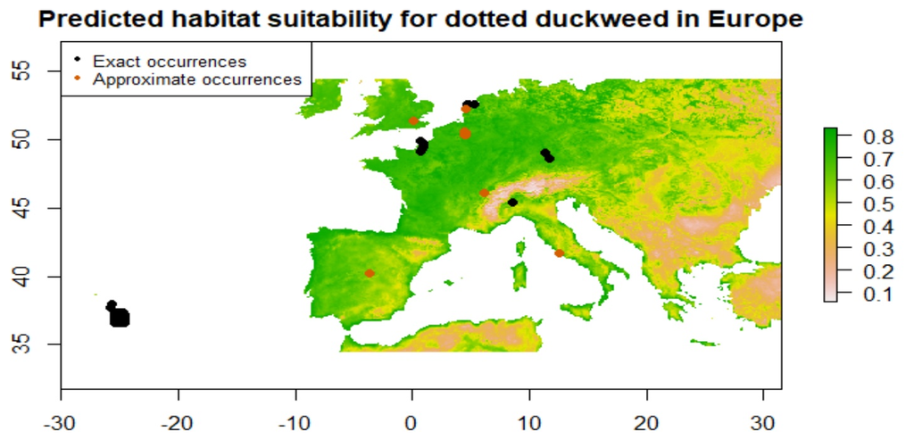

## Preliminary results and discussion

- Future temperature predictions (climate change):
  - Currently compatible areas will still be suitable in 2070
  - Great Lakes region will become suitable for this species
- Preventive measures to avoid *L. punctata* further spread are recommended in these locations to avoid a similar invasion scenario as seen in a related duckweed species in Europe or in *L. punctata* in the US

## Next steps

- Complete surface area measurements and perform statistical analysis: 2023-2024
- Complete night warming experiment (effects of warmer nights in a hot summer): Feb, 2024
- Complete distribution model manuscript and submit for publication: Dec, 2023
- Conduct population experiments (several generations): 2024
- Develop population models: 2024
- Write night warming and autocorrelation manuscripts: 2024